# Requête HTTP

## Introduction

HTTP est un protocole qui permet de récupérer des ressources comme les documents HTML, des images ou autres médias. Il est à la base de tout échange de données sur le Web. C'est un protocole de type **client-serveur**.

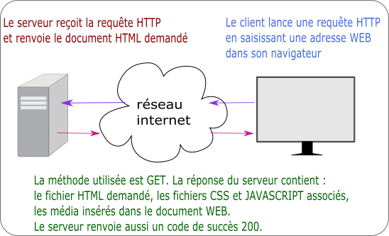

## Les méthodes d'une requête HTTP

Une requête HTTP possède deuxs méthodes d'envoi:

- La methode **GET** qui récupère du serveur les données HTML du document demandé;
- La méthode **POST** qui envoie au serveur des données (formulaire);

Le serveur répond à la requête selon la méthode utilisée. Sa réponse contient un code d'état. Les codes d'état sont classés par catégorie.

Les plus courants sont :

- Si la requête est un succès, le code d'état vaut 200;
- Si la requête a été redirigée vers un autre site web, le code d'état vaut 301;
- Si la ressource n'est pas accessible, accès refusé, le code d'état vaut 403;
- Si la ressource demandée n'est pas trouvée, le code vaut 404;
- Si le serveur ne peut pas répondre (panne), le code vaut 500;

Les requêtes HTTP se réalisent avec des navigateurs. On les rencotre donc dans le monde du WEB. Toutefois, il existe d'autre applications qui effectuent des requêtes HTTP. Certains programmes comme **CURL** s'utilisent en ligne de commande (mode console) et permettent de récupérer des ressources sous forme de fichier.

En Python, il existe un module **requests** qui permet de programmer des requêtes HTTP afin de récupérer des données et les exploiter à travers un programme.

## La méthode GET

Un navigateur comme **firefox**, **chrome** ou **edge** effectue une requête **GET** dès que l'on demande d'accéder à une page WEB. La requête est construite autour de l'**url** saisie dans la barre d'adresse du navigateur.

### Exemple de requête HTTP avec la méthode GET

Dans un navigateur, on saisit une url : https://interstices.info/intelligence-artificielle-intelligence-humaine/

Le navigateur envoie une requête au serveur qui héberge la page WEB demandée.

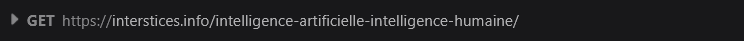

L'en-tête de la requête contient de nombreuses informations dont :

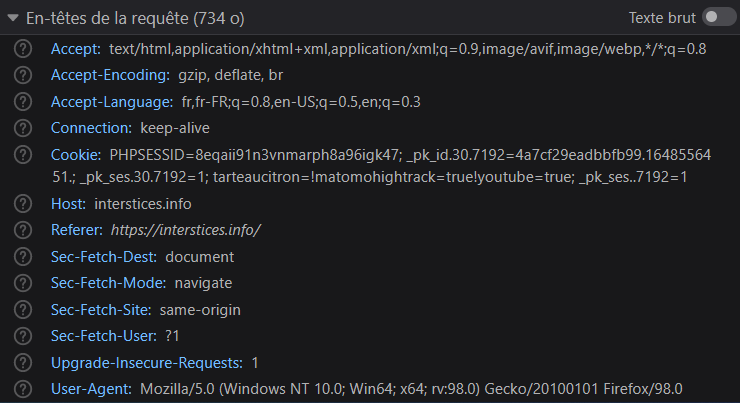

### Réponse HTTP avec la méthode GET

Suite à la requête d'un client avec la méthode **GET**, le serveur traite la requête et répond. Si la ressource demandée est trouvée, il la renvoie avec un code d'état:

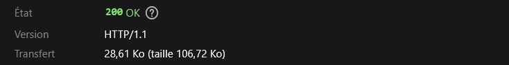

Le code d'état de la réponse est **200** ce qui signifie que la ressource demandée a été trouvée et envoyée au client et le statut **OK**.

Avec la ressource demandée, un en-tête de réponse est ajouté et contient les éléments suivants:

- Le type de contenu et son encodage : text/html; charset=UTF-8
- la taille du contenu : $28722$ octets.
- La date et l'heure de l'envoi : 29 mars 2022
- Le serveur utilise l'application **Apache** qui est un serveur WEB,
- La connexion est fermée après l'envoi.

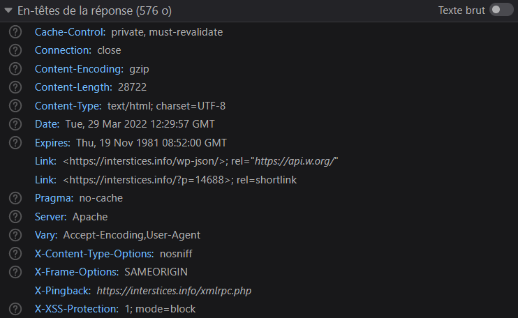

## Méthode GET avec paramètres

La méthode **GET** permet d'envoyer des paramètres au serveur qui les traitera et adaptera sa réponse aux valeurs attribuées à ces paramètres.

La syntaxe utilise :

- le **point d'interrogation ?** pour séparer l'url des paramètres,
- les paramètres et les valeurs reliées par le signe **égal =**,
- les différents paramètres sont séparés par des **esperluettes &**.

### Exemple de requête GET avec paramètres

Cette méthode est utilisée lorsqu'on utilise le moteur de recherche d'un site. On peut facilement l'observer avec le moteur de recherche de Google.

[figure not shown]

Lorsque le champ du formulaire est complété par les mots **python** et **requête**, le navigateur construit une requête avec la méthode **GET** qui est:

La requête contient à la suite de l'url **https://www.google.fr/search** le point d'interrogation **?**, le paramètre **q=** et la valeur **python+requête**. On peut remarquer que d'autres paramètres sont ajoutés automatiquement.

La requête **GET** est très longue et contient de nombreux paramètres qui seront traités par **google** et affineront la recherche.

[figure not shown]

## Méthode POST

La méthode POST permet d'envoyer des valeurs au serveur. Ces valeurs sont associées à des paramètres dans un tableau associatif, qui est une sorte de dictionnaire Python. Ce tableau associatif est placé dans le **corps de la requête** et non dans l'url (comme avec la méthode GET).

L'usage d'un formulaire dans la page web est alors employé pour présenter les différents paramètres et les zones de saisie permettent d'y associer les valeurs. Un bouton d'envoi provoque l'envoi des données.

### Exemple de requête POST

Les sites contiennent une page de contact qui permet d'envoyer un message aux responsables du site ou une page d'authentification pour accéder à des contenus privés.

Par exemple, pour ajouter du contenu à un blog, je dois me connecter avec mon **login** et mon **mot de passe**. La page d'authentification propose un formulaire avec deux champs.

[figure not shown]

Après avoir renseigné ces deux champs, je valide le formulaire et le navigateur effectue une requête avec la méthode **POST**. Les valeurs saisies sont envoyées au serveur sous la forme d'un tableau associatif (en JSON ici) :

[output not shown]

Les données ne sont pas ajoutées à l'url ! Si tel était le cas, ce serait un problème pour la sécurité et la confidentialité des données.

Les données de la requête **POST** sont placées dans le **corps de la requête**.

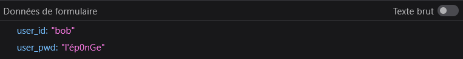

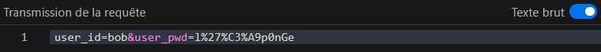

Après l'envoi, les données de la requête sont traitées par le serveur et plus précisément par un script qui va construire une réponse et la renvoyer au client.

Les requêtes HTTP avec la méthode POST nécessitent un traitement des données et l'envoi d'une réponse vers le client. On parle dans ce cas de **page web dynamique**.